# Używanie narzędzi AI wśród studentów

Barbara Dudek

2026-01-21

# Wprowadzenie

## Pakiety których będę używać:

```r
library(knitr)
library(dplyr)
library(ggplot2)
library(psych)
library(mice)
library(corrplot)
library(ggthemes)
```

## Opis

W obecnych czasach rośnie zainteresowanie sztuczną inteligencją, a narzędzia wspierane przez Artificial Intelligence towarzyszą nam niemal na każdym kroku.

Rozwój tej technologii budzi wiele kontrowersji m.in. etyczne, prawne i edukacyjne. Często wynika to z faktu niewystarczającej (lub braku) regulacji użytkowania AI lub świadomości użytkowników.

Większość źródeł internetowych w Polsce cytuje analizy przeprowadzonych badań przez KPMG. Badania te pokazują ciekawe statystyki, w których aż 84% badanych Polaków przyznaje się do używania narzędzi AI. Dodatkowo wśród ankietowanych każdy uczeń przyznał, że używa ich do celów edukacyjnych. Dane te potwierdzają, że technologia ta odgrywa coraz większą rolę w naszym życiu, także w procesie kształcenia.

[figure not shown]

```r
include_graphics("użycieAIPolska.jpg")
```

Niniejsza EDA dotyczy używania narzędzi AI przez studentów w celach edukacyjnych. Ze względu na ograniczoną dostępność szczegółowych danych dot. studentów w Polsce, w projekcie wykorzystuję zbiór danych odnoszący się do studentów z Indii. Różnice kulturowe, systemowe oraz edukacyjne mogą wpływać na sposób korzystania z narzędzi sztucznej inteligencji, dlatego ta analiza nie powinna stanowić odniesienia dla ogółu studentów z Polski czy ze świata.

## O zestawie danych

Wybrałam zestaw danych umieszczonych na platformie *https://www.kaggle.com* o nazwie **AI Tool Usage by Indian College Students 2025** opracowany przez **Rakesh Kapilavayi**. Dane powstały na podstawie przeprowadzonych ankiet wśród studentów z różnych uczelni na terenie Indii. Plik zawiera 16 zmiennych (jakościowych i ilościowych) i 3614 obserwacji.

## Zmienne

- **Student_Name** *Imię studenta zmienione na potrzeby publikacji*
- **College_Name** *Nazwa uczelni*
- **Stream** *Dziedzina/Rodzaj studiów (np. Inżynieria, Artystyczne)*
- **Year_of_Study** *Rok studiów (1-4)*
- **AI_Tools_Used** *Użyte narzędzie AI*
- **Daily_Usage_Hours** *Dzienny czas użycia narzędzi AI w godzinach*
- **Use_Cases** *Powody użycia sztucznej inteligencji*
- **Trust_in_AI_Tools** *Zaufanie do AI w skali 1-5*
- **Impact_on_Grades** *Wpływ na oceny - zakres od -5 do +5*
- **Do_Professors_Allow_Use** *Czy jest przyzwolenie wykładowcy? (Tak/Nie)*
- **Preferred_AI_Tool** *Preferowane narzędzie AI*
- **Awareness_Level** *Poziom świadomości na temat AI w skali 1–10*
- **Willing_to_Pay_for_Access** *Chęć/gotowość do płacenia za dostęp (Tak/Nie)*
- **State** *Stan w Indiach*
- **Device_Used** *Używane urządzenie (np. Laptop, Smartfon)*
- **Internet_Access** *Jakość dostępu do internetu (słaba/średnia/wysoka)*

# Przygotowanie danych

## Wczytanie pliku

```r
studenci_AI <- read.csv("students.csv", sep = ",")
```

## Zapoznanie się z danymi

```r
head(studenci_AI, 10)
```

|  | Student_Name | College_Name | Stream | Year_of_Study | AI_Tools_Used | Daily_Usage_Hours | Use_Cases | Trust_in_AI_Tools | Impact_on_Grades | Do_Professors_Allow_Use | Preferred_AI_Tool | Awareness_Level | Willing_to_Pay_for_Access | State | Device_Used | Internet_Access |
| --- | --- | --- | --- | --- | --- | --- | --- | --- | --- | --- | --- | --- | --- | --- | --- | --- |
| 1 | Aarav | Indian Institute of Information Technology | Engineering | 4 | Gemini | 0.9 | Assignments, Coding Help | 2 | 2 | No | Copilot | 9 | Yes | Uttar pradesh | Mobile | Poor |
| 2 | Vivaan | Government Ram Bhajan Rai NES College, Jashpur | Commerce | 2 | ChatGPT | 3.4 | Learning new topics | 3 | -3 | Yes | Other | 6 | No | Chhattisgarh | Laptop | Poor |
| 3 | Aditya | Dolphin PG Institute of BioMedical & Natural | Science | 2 | Copilot | 3.6 | MCQ Practice, Projects | 5 | 0 | No | Gemini | 1 | No | Uttarakhand | Tablet | Poor |
| 4 | Vihaan | Shaheed Rajguru College of Applied Sciences for | Arts | 2 | Copilot | 2.9 | Content Writing | 5 | 2 | Yes | Gemini | 5 | No | Delhi ncr | Laptop | High |
| 5 | Arjun | Roorkee College of Engineering | Science | 1 | Gemini | 0.9 | Doubt Solving, Resume Writing | 1 | 3 | Yes | Other | 8 | Yes | Uttarakhand | Laptop | Medium |
| 6 | Sai | Kanya Mahavidyalaya | Commerce | 2 | Gemini | 0.8 | Doubt Solving, Resume Writing | 2 | -2 | Yes | Gemini | 7 | No | Punjab | Laptop | High |
| 7 | Reyansh | Shivalik Institute of Paramedical Technology | Medical | 1 | ChatGPT, Gemini, Copilot | 2.2 | Assignments, Coding Help | 1 | -1 | Yes | Other | 2 | No | Chandigarh | Mobile | Medium |
| 8 | Ayaan | Alpha College of Engineering & Technology, Pondicherry | Engineering | 4 | ChatGPT, Copilot | 2.4 | Exam Prep, Notes | 2 | -2 | Yes | Copilot | 5 | Yes | Puducherry | Mobile | High |
| 9 | Krishna | Jaipur Engineering College and Research Centre, Jaipur | Engineering | 4 | ChatGPT, Copilot | 2.1 | MCQ Practice, Projects | 2 | -2 | Yes | Copilot | 8 | Yes | Rajasthan | Laptop | Poor |
| 10 | Ishaan | ICFAI University, Shillong | Commerce | 2 | Gemini | 1.4 | Content Writing | 3 | -2 | No | Gemini | 3 | Yes | Meghalaya | Laptop | High |

```r
tail(studenci_AI)
```

|  | Student_Name | College_Name | Stream | Year_of_Study | AI_Tools_Used | Daily_Usage_Hours | Use_Cases | Trust_in_AI_Tools | Impact_on_Grades | Do_Professors_Allow_Use | Preferred_AI_Tool | Awareness_Level | Willing_to_Pay_for_Access | State | Device_Used | Internet_Access |
| --- | --- | --- | --- | --- | --- | --- | --- | --- | --- | --- | --- | --- | --- | --- | --- | --- |
| 3609 | Krishna | National Institute of Technology | Arts | 1 | Gemini, Midjourney | 3.9 | Assignments, Coding Help | 5 | 2 | Yes | Copilot | 7 | Yes |  | Mobile | Poor |
| 3610 | Ishaan | St. Mira's College for Girls, Pune | Commerce | 1 | ChatGPT, Copilot | 4.3 | Doubt Solving, Resume Writing | 2 | 2 | Yes | Other | 2 | No |  | Mobile | High |
| 3611 | Rudra | Roorkee College of Pharmacy | Pharmacy | 3 | Copilot | 3.0 | Content Writing | 2 | 1 | No | Copilot | 5 | Yes |  | Tablet | Poor |
| 3612 | Dhruv | Bahona College, Jorhat | Agriculture | 3 | Gemini | 2.7 | Exam Prep, Notes | 2 | 1 | Yes | Copilot | 3 | No |  | Tablet | Poor |
| 3613 | Kabir | Sree Chitra Thirunal College of Engineering | Engineering | 4 | Gemini | 2.7 | Exam Prep, Notes | 3 | 3 | Yes | Gemini | 3 | No |  | Laptop | High |
| 3614 | Atharv | Poona College of Pharmacy, Pune | Pharmacy | 3 | Copilot | 0.9 | Exam Prep, Notes | 1 | 2 | No | Copilot | 2 | No |  | Mobile | High |

Powyżej pokazało mi się dziesięć pierwszych i 6 ostatnich wierszy. Jak widać zmienne Use_Cases oraz AI_Tools_Used nie będą łatwe do analizy, ze względu na wielokrotne wartości w komórkach.

## Poznanie struktury

```r
str(studenci_AI)
```

```
## 'data.frame':    3614 obs. of  16 variables:
##  $ Student_Name             : chr  "Aarav" "Vivaan" "Aditya" "Vihaan" ...
##  $ College_Name             : chr  "Indian Institute of Information Technology " "Government Ram Bhajan Rai NES College, Jashpur " "Dolphin PG Institute of BioMedical & Natural " "Shaheed Rajguru College of Applied Sciences for " ...
##  $ Stream                   : chr  "Engineering" "Commerce" "Science" "Arts" ...
##  $ Year_of_Study            : int  4 2 2 2 1 2 1 4 4 2 ...
##  $ AI_Tools_Used            : chr  "Gemini" "ChatGPT" "Copilot" "Copilot" ...
##  $ Daily_Usage_Hours        : num  0.9 3.4 3.6 2.9 0.9 0.8 2.2 2.4 2.1 1.4 ...
##  $ Use_Cases                : chr  "Assignments, Coding Help" "Learning new topics" "MCQ Practice, Projects" "Content Writing" ...
##  $ Trust_in_AI_Tools        : int  2 3 5 5 1 2 1 2 2 3 ...
##  $ Impact_on_Grades         : int  2 -3 0 2 3 -2 -1 -2 -2 -2 ...
##  $ Do_Professors_Allow_Use  : chr  "No" "Yes" "No" "Yes" ...
##  $ Preferred_AI_Tool        : chr  "Copilot" "Other" "Gemini" "Gemini" ...
##  $ Awareness_Level          : int  9 6 1 5 8 7 2 5 8 3 ...
##  $ Willing_to_Pay_for_Access: chr  "Yes" "No" "No" "No" ...
##  $ State                    : chr  "Uttar pradesh" "Chhattisgarh" "Uttarakhand" "Delhi ncr" ...
##  $ Device_Used              : chr  "Mobile" "Laptop" "Tablet" "Laptop" ...
##  $ Internet_Access          : chr  "Poor" "Poor" "Poor" "High" ...
```

W oryginalnym pliku z danymi występują 3 typy zmiennych: character (ciąg znaków/tekst), numeric (liczby zmiennoprzecinkowe) i integer (liczby całkowite).

## Poznanie zmiennych i ich rozkładów, zamiana typów

Teraz czas na poznanie zmiennych. Na potrzeby analizy wiele ze zmiennych zmienię na typ factor. Tym, w których kolejność może mieć znaczenie, nadam kategorie/ poziomy.

### Zmienne liczbowe

Jedna z najciekawszych zmiennych, czyli zaufanie do AI:

```r
table(studenci_AI$Trust_in_AI_Tools)
```

```
##
##   1   2   3   4   5
## 714 750 685 668 797
```

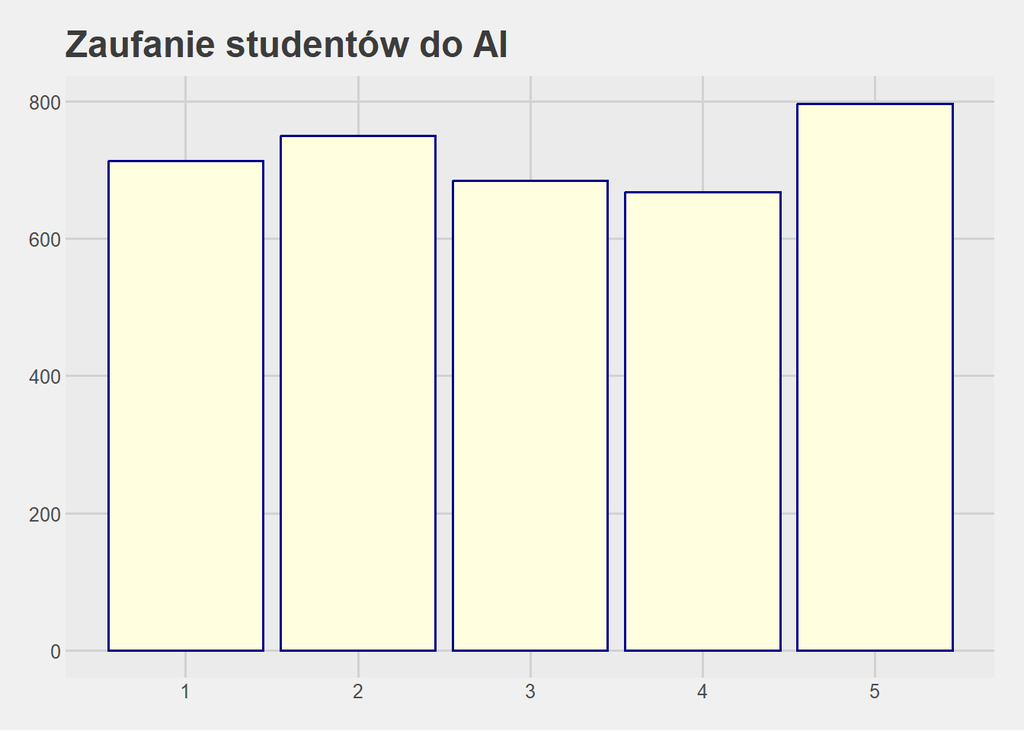

```r
studenci_AI %>%
  ggplot() +
  geom_bar(aes(x = Trust_in_AI_Tools),
                 color = "darkblue", fill = "lightyellow") +
  theme_fivethirtyeight() +
  labs(title = "Zaufanie studentów do AI",
       x = "stopień zaufania",
       y = "ilość studentów")
```

Jest to ocena, zostawiam ją w postaci liczbowej, co pozwoli mi na liczenie statystyk opisowych, a nie tylko określanie kierunku wpływu. Zaufanie jest dość zróżnicowane.

Poznanie zmiennych Daily_Usage_Hours - dzienny czas używania, Impact_on_Grades - wpływ na oceny oraz Awareness_Level - poziom świadomości:

```r
table(studenci_AI$Daily_Usage_Hours)
```

```
##
## 0.5 0.6 0.7 0.8 0.9   1 1.1 1.2 1.3 1.4 1.5 1.6 1.7 1.8 1.9   2 2.1 2.2 2.3 2.4
##  37 105  88 114 104  66  83  81 108 109  83  64  76  79 119  93  60  77  95  56
## 2.5 2.6 2.7 2.8 2.9   3 3.1 3.2 3.3 3.4 3.5 3.6 3.7 3.8 3.9   4 4.1 4.2 4.3 4.4
##  53  98  83  64  88  89 118 113  79 105  68  89  87 102 100  76 135  85  68  86
## 4.5 4.6 4.7 4.8 4.9   5
##  41  19  14  23  26   8
```

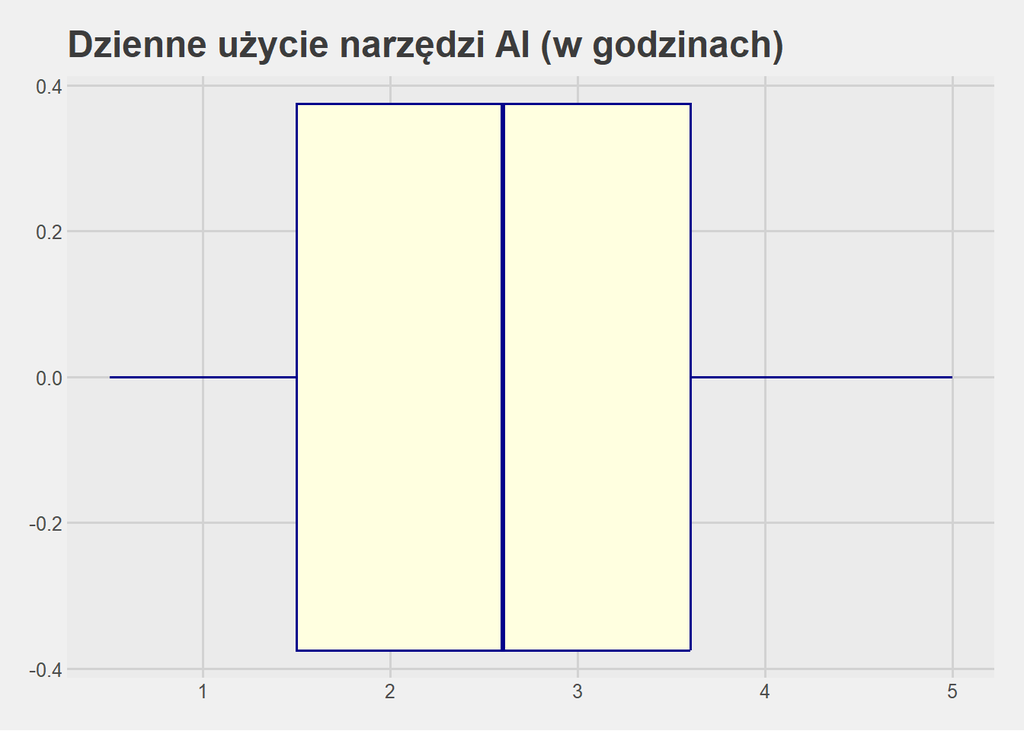

```r
studenci_AI %>%
  ggplot() +
  geom_boxplot(aes(x = Daily_Usage_Hours),
                 color = "darkblue", fill = "lightyellow") +
  theme_fivethirtyeight() +
  labs(title = "Dzienne użycie narzędzi AI (w godzinach)",
       x = "godziny")
```

```r
table(studenci_AI$Impact_on_Grades)
```

```
##
##  -5  -4  -3  -2  -1   0   1   2   3   4   5
##  84 110 463 445 446 465 477 523 419  93  89
```

```r
table(studenci_AI$Awareness_Level)
```

```
##
##   1   2   3   4   5   6   7   8   9  10
## 312 347 362 275 302 357 385 376 463 435
```

Brak zmiany typu, tutaj dane liczbowe dają najwięcej możliwości. Przy zmiennej dot. czasu używania może zajść potrzeba uproszczenia wartości, np. wprowadzenia przedziałów (wartości są z przedziału 0,5 - 5[h], co 0,1 h i o liczebności od 8 do 135 osób przy każdej z wartości).

### Zmienne jakościowe zamienione na typ factor

Teraz poznaję zmienną Stream - dziedzina studiów:

```r
table(studenci_AI$Stream)
```

```
##
##      Agriculture             Arts         Commerce      Engineering
##              262              413              364              505
## Hotel-management              Law       Management          Medical
##              318              246              380              281
##         Pharmacy          Science
##              252              593
```

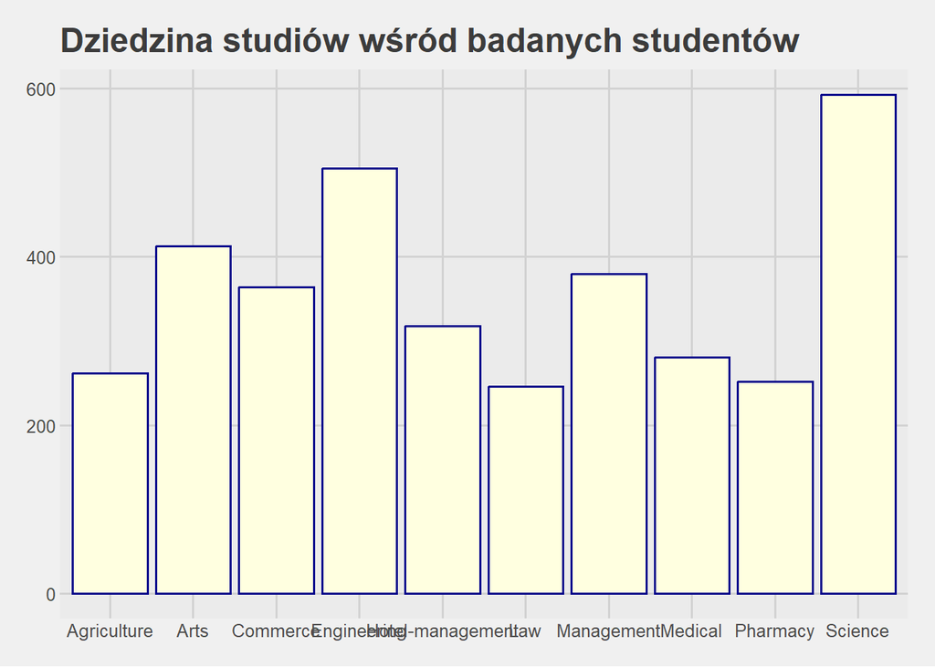

```r
studenci_AI$Stream <- as.factor(studenci_AI$Stream)
studenci_AI %>%
  ggplot() +
  geom_bar(aes(x = Stream),
           color = "darkblue", fill = "lightyellow") +
  theme_fivethirtyeight() +
  labs(title = "Dziedzina studiów wśród badanych studentów",
       x = "Dziedzina",
       y = "Ilość studentów")
```

Ta zmienna na pewno będzie użyteczna jako typ factor. Kolejność bez znaczenia. Widać wyraźne różnice pomiędzy liczebnością grup, dominują kierunki ścisłe.

Czas na zmienną Year_of_Study:

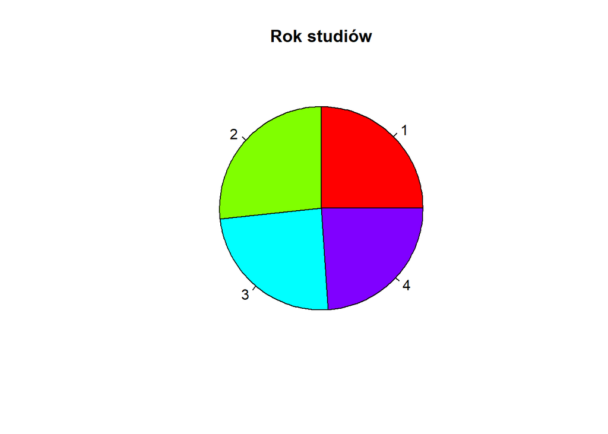

```r
studenci_AI$Year_of_Study <- as.factor(studenci_AI$Year_of_Study)
levels(studenci_AI$Year_of_Study) <- 1:4
pie(table(studenci_AI$Year_of_Study),
    main = "Rok studiów",
    col = rainbow(4))
```

Rok studiów traktuję jako zmienną porządkową, obliczanie statystyk opisowych nie wniosłoby nic do analizy, dlatego postanowiłam zmienić typ na factor i nadać poziomy. Wykres kołowy przedstawia rozkład zmiennej, przeważa rok 2.

Jako następną sprawdzam zmienną AI_Tools_Used.

```r
table(studenci_AI$AI_Tools_Used)
```

```
##
##                     Bard                  ChatGPT         ChatGPT, Copilot
##                      151                      626                      505
## ChatGPT, Gemini, Copilot                   Claude                  Copilot
##                      426                      171                      585
##                   Gemini       Gemini, Midjourney                    Other
##                      612                      371                      167
```

```r
studenci_AI$AI_Tools_Used <- as.factor(studenci_AI$AI_Tools_Used)
```

Część rekordów tej zmiennej w zbiorze danych ma wielokrotne wartości, jednak są one dość powtarzalne, dlatego postanowiłam zamienić typ na factor.

Zmienna przyzwolenia profesorów na używanie AI:

```r
table(studenci_AI$Do_Professors_Allow_Use)
```

```
##
##   No  Yes
## 1886 1728
```

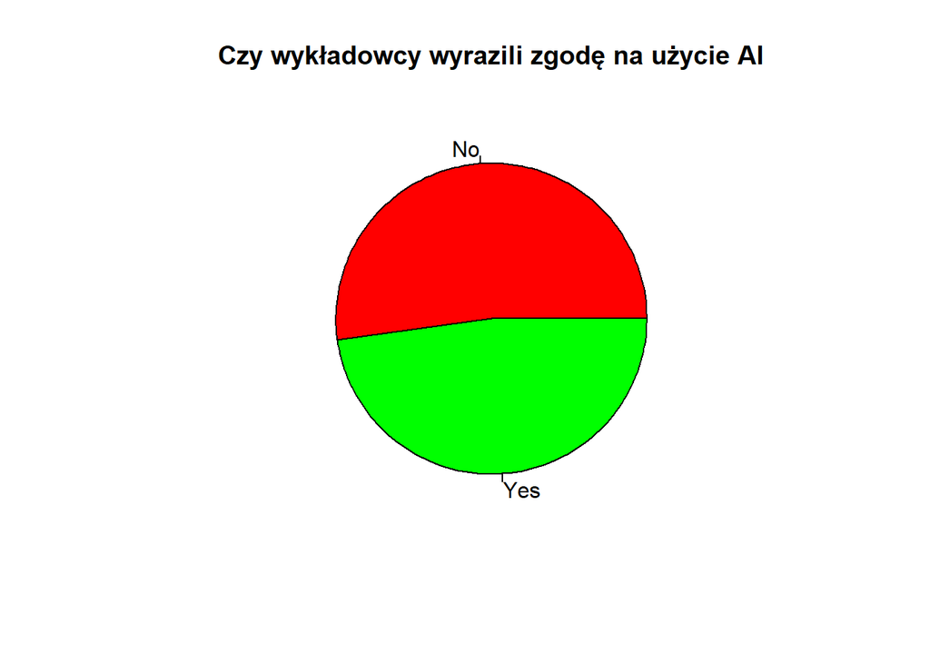

```r
studenci_AI$Do_Professors_Allow_Use <- as.factor(studenci_AI$Do_Professors_Allow_Use)
pie(table(studenci_AI$Do_Professors_Allow_Use),
    main = "Czy wykładowcy wyrazili zgodę na użycie AI",
    col = c("red", "green"))
```

Zmieniam na factor, bez znaczenia kolejność. Jednym z prostszych wykresów do tego typów danych jest wykres kołowy. Z łatwością można zauważyć przewagę odpowiedzi “Nie”.

Poznaję kolejną zmienną:

```r
table(studenci_AI$Preferred_AI_Tool)
```

```
##
##    Bard ChatGPT  Claude Copilot  Gemini   Other
##     151     859     157     836     854     757
```

```r
studenci_AI$Preferred_AI_Tool <- as.factor(studenci_AI$Preferred_AI_Tool)
```

Preferowane narzędzie AI będzie przydatne, dlatego zmieniam na factor. Tutaj także kolejność nie ma znaczenia

Chęć do płacenia za narzędzia AI ma strukturę Tak/Nie, więc zmieniam ją na factor

```r
studenci_AI$Willing_to_Pay_for_Access <- as.factor(studenci_AI$Willing_to_Pay_for_Access)
```

Poznaję strukturę zmiennej State:

```r
table(studenci_AI$State)
```

```
##
##                             Andaman    Andhra pradesh Arunachal pradesh
##              1614                 5                90                35
##             Assam             Bihar        Chandigarh      Chhattisgarh
##                79                75                41                81
##             Dadra         Delhi ncr               Goa           Gujarat
##                 2                70                35                85
##           Haryana  Himachal pradesh             Jammu         Jharkhand
##                79                58                59                52
##         Karnataka            Kerala    Madhya pradesh       Maharashtra
##                90                88                79               106
##           Manipur         Meghalaya           Mizoram          Nagaland
##                20                35                10                24
##            Orissa        Puducherry            Punjab         Rajasthan
##                62                23                93                94
##            Sikkim        Tamil nadu         Telangana           Tripura
##                16                85                64                19
##     Uttar pradesh       Uttarakhand       West bengal
##                96                71                79
```

```r
studenci_AI$State <- as.factor(studenci_AI$State)
```

Może się okazać pomocna w badaniu wpływu, postanowiłam zamienić jej typ na factor.

Zmienna pokazująca jakie urządzenia wykorzystano do użycia narzędzi sztucznej inteligencji :

```r
table(studenci_AI$Device_Used)
```

```
##
## Laptop Mobile Tablet
##   1336   1086   1192
```

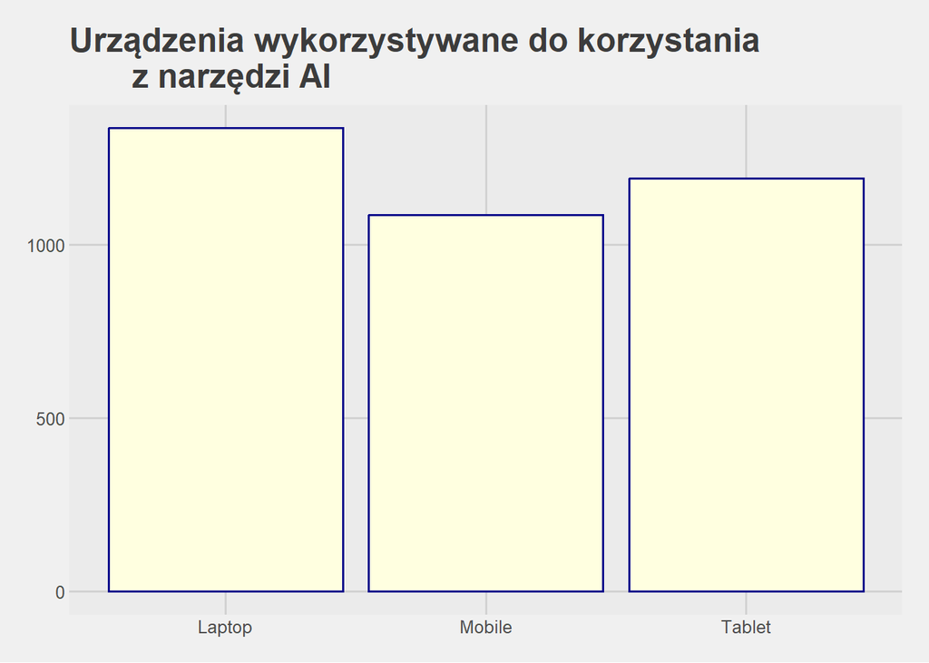

```r
studenci_AI$Device_Used <- as.factor(studenci_AI$Device_Used)
studenci_AI %>%
  ggplot(aes(x = Device_Used)) +
  geom_bar(fill = "lightyellow", colour = "darkblue") +
  theme_fivethirtyeight() +
  labs(title = "Urządzenia wykorzystywane do korzystania
       z narzędzi AI",
       x = "Urządzenie",
       y = "Ilość studentów")
```

Jakość dostępu do internetu także zmieniam na typ faktor:

```r
table(studenci_AI$Internet_Access)
```

```
##
##   High Medium   Poor
##   1124   1260   1230
```

```r
studenci_AI$Internet_Access <- as.factor(studenci_AI$Internet_Access)
```

### Zmienne identyfikacyjne i tekstowe

Zmienną zawierającą imiona studentów pomijam, ponieważ nie ma znaczenia w mojej EDA. Kolejną zmienną jest Nazwa uczelni - College_Name, przy próbie poznania struktury okazało się, że rozróżnia bardzo dużo wartości. W mojej EDA nie będę używać tej zmiennej, dlatego nie zmieniam typu.

```r
#table(studenci_AI$College_Name)
```

Sprawdzając powtarzające się dane w kolumnie Use_Cases napotkałam problem z unikalnością danych (ponad 300). Część powodów powtarza się, jednak ze względu na pozmienianą kolejność wpisywania, program rozróżnia je jako inne wartości. Duplikowanie wierszy zaburzyłoby statystykę (m.in. sztucznie zwiększyłoby próbę), a zmiana na typ factor nie wniosłaby nic do statystyki. Dlatego postanowiłam nie ingerować w tę zmienną, a jeżeli w analizie uznam to za zasadne, poszczególne powody użycia AI będę weryfikować za pomocą wyszukiwania frazy tekstowej. (Kod poniżej jest umieszczony jako komentarz ze względów estetycznych- bardzo długa tabela.)

```r
#table(studenci_AI$Use_Cases)
```

## Sprawdzanie braków i wartości odstających

W celu sprawdzenia występowania brakujących danych używam funkcji md.pattern() z pakietu **mice**.

```
##  /\     /\
## {  `---'  }
## {  O   O  }
## ==>  V <==  No need for mice. This data set is completely observed.
##  \  \|/  /
##   `-----'
```

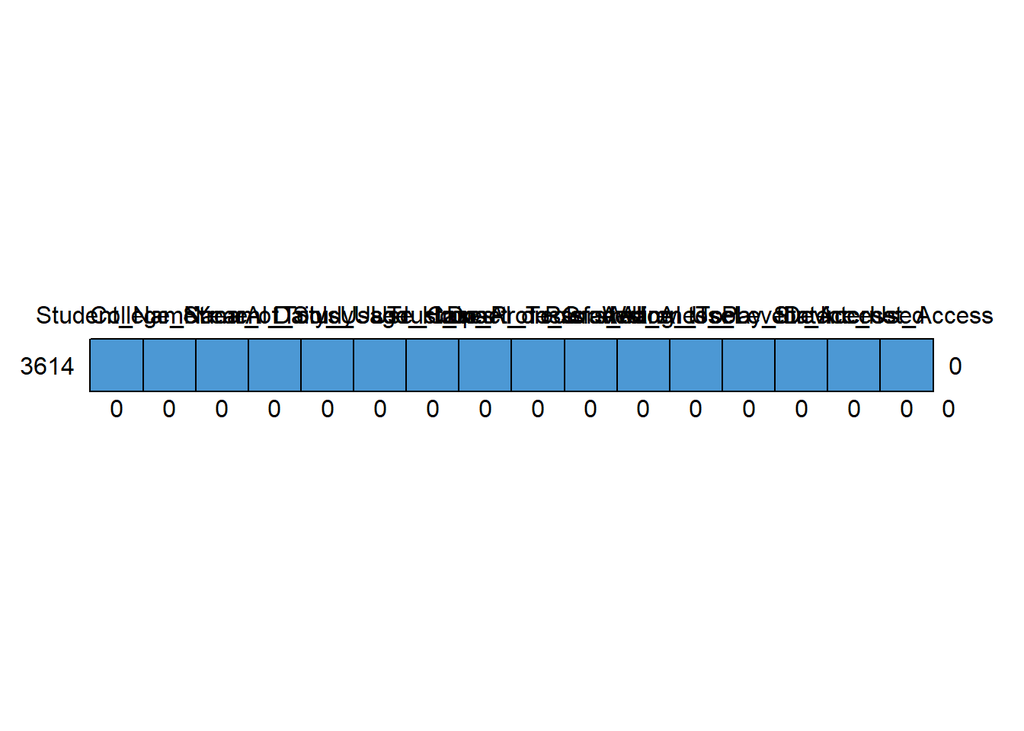

```
##      Student_Name College_Name Stream Year_of_Study AI_Tools_Used
## 3614            1            1      1             1             1
##                 0            0      0             0             0
##      Daily_Usage_Hours Use_Cases Trust_in_AI_Tools Impact_on_Grades
## 3614                 1         1                 1                1
##                      0         0                 0                0
##      Do_Professors_Allow_Use Preferred_AI_Tool Awareness_Level
## 3614                       1                 1               1
##                            0                 0               0
##      Willing_to_Pay_for_Access State Device_Used Internet_Access
## 3614                         1     1           1               1 0
##                              0     0           0               0 0
```

```r
md.pattern(studenci_AI)
```

```r
summary(studenci_AI)
```

```
##  Student_Name       College_Name                    Stream     Year_of_Study
##  Length:3614        Length:3614        Science         : 593   1:902
##  Class :character   Class :character   Engineering     : 505   2:966
##  Mode  :character   Mode  :character   Arts            : 413   3:881
##                                        Management      : 380   4:865
##                                        Commerce        : 364
##                                        Hotel-management: 318
##                                        (Other)         :1041
##                   AI_Tools_Used Daily_Usage_Hours  Use_Cases
##  ChatGPT                 :626   Min.   :0.50      Length:3614
##  Gemini                  :612   1st Qu.:1.50      Class :character
##  Copilot                 :585   Median :2.60      Mode  :character
##  ChatGPT, Copilot        :505   Mean   :2.56
##  ChatGPT, Gemini, Copilot:426   3rd Qu.:3.60
##  Gemini, Midjourney      :371   Max.   :5.00
##  (Other)                 :489
##  Trust_in_AI_Tools Impact_on_Grades   Do_Professors_Allow_Use Preferred_AI_Tool
##  Min.   :1.000     Min.   :-5.00000   No :1886                Bard   :151
##  1st Qu.:2.000     1st Qu.:-2.00000   Yes:1728                ChatGPT:859
##  Median :3.000     Median : 0.00000                           Claude :157
##  Mean   :3.023     Mean   : 0.00332                           Copilot:836
##  3rd Qu.:4.000     3rd Qu.: 2.00000                           Gemini :854
##  Max.   :5.000     Max.   : 5.00000                           Other  :757
##
##  Awareness_Level  Willing_to_Pay_for_Access            State      Device_Used
##  Min.   : 1.000   No :1811                                :1614   Laptop:1336
##  1st Qu.: 3.000   Yes:1803                  Maharashtra   : 106   Mobile:1086
##  Median : 6.000                             Uttar pradesh :  96   Tablet:1192
##  Mean   : 5.828                             Rajasthan     :  94
##  3rd Qu.: 8.000                             Punjab        :  93
##  Max.   :10.000                             Andhra pradesh:  90
##                                             (Other)       :1521
##  Internet_Access
##  High  :1124
##  Medium:1260
##  Poor  :1230
##
##
##
##
```

```r
studenci_AI %>%
  select(Daily_Usage_Hours, Trust_in_AI_Tools, Impact_on_Grades, Awareness_Level) %>%
  describe()
```

|  | vars | n | mean | sd | median | trimmed | mad | min | max | range | skew | kurtosis | se |
| --- | --- | --- | --- | --- | --- | --- | --- | --- | --- | --- | --- | --- | --- |
| Daily_Usage_Hours | 1 | 3614 | 2.559684560 | 1.213319 | 2.6 | 2.557261411 | 1.63086 | 0.5 | 5 | 4.5 | -0.0002959022 | -1.2043979 | 0.02018278 |
| Trust_in_AI_Tools | 2 | 3614 | 3.023242944 | 1.436934 | 3.0 | 3.029045643 | 1.48260 | 1.0 | 5 | 4.0 | 0.0057611425 | -1.3408156 | 0.02390247 |
| Impact_on_Grades | 3 | 3614 | 0.003320421 | 2.370706 | 0.0 | 0.006569848 | 2.96520 | -5.0 | 5 | 10.0 | -0.0248848092 | -0.8278823 | 0.03943517 |
| Awareness_Level | 4 | 3614 | 5.828444936 | 2.925481 | 6.0 | 5.893499308 | 4.44780 | 1.0 | 10 | 9.0 | -0.1527032971 | -1.2691719 | 0.04866348 |

Funkcja summary() przedstawiła statystyki opisowe i rozkłady poszczególnych zmiennych, w większości danych funkcja nie wskazuje na wartości odstające.

Funkcja psych:: describe() pokazuje podstawowe statystyki opisowe: średnią, odchylenie standardowe, zakres zmienności, oraz miary skośności i kurtozy. Wybrałam do niej tylko dane liczbowe. W dalszej części przedstawię graficznie rozkłady i zależności wybranych danych.

# Analiza zbioru danych

## Zależności między zmiennymi

Zaczynam od wstępnej analizy zależności między zmiennymi liczbowymi. W tym celu tworzę macierz korelacji Spearmana.

```r
cor_studenci <- cor(
  studenci_AI[, c("Daily_Usage_Hours", "Trust_in_AI_Tools",
                  "Impact_on_Grades", "Awareness_Level")],
  method = "spearman")

round(cor_studenci, 2)
```

```
##                   Daily_Usage_Hours Trust_in_AI_Tools Impact_on_Grades
## Daily_Usage_Hours              1.00             -0.01             0.06
## Trust_in_AI_Tools             -0.01              1.00            -0.05
## Impact_on_Grades               0.06             -0.05             1.00
## Awareness_Level                0.00              0.04            -0.01
##                   Awareness_Level
## Daily_Usage_Hours            0.00
## Trust_in_AI_Tools            0.04
## Impact_on_Grades            -0.01
## Awareness_Level              1.00
```

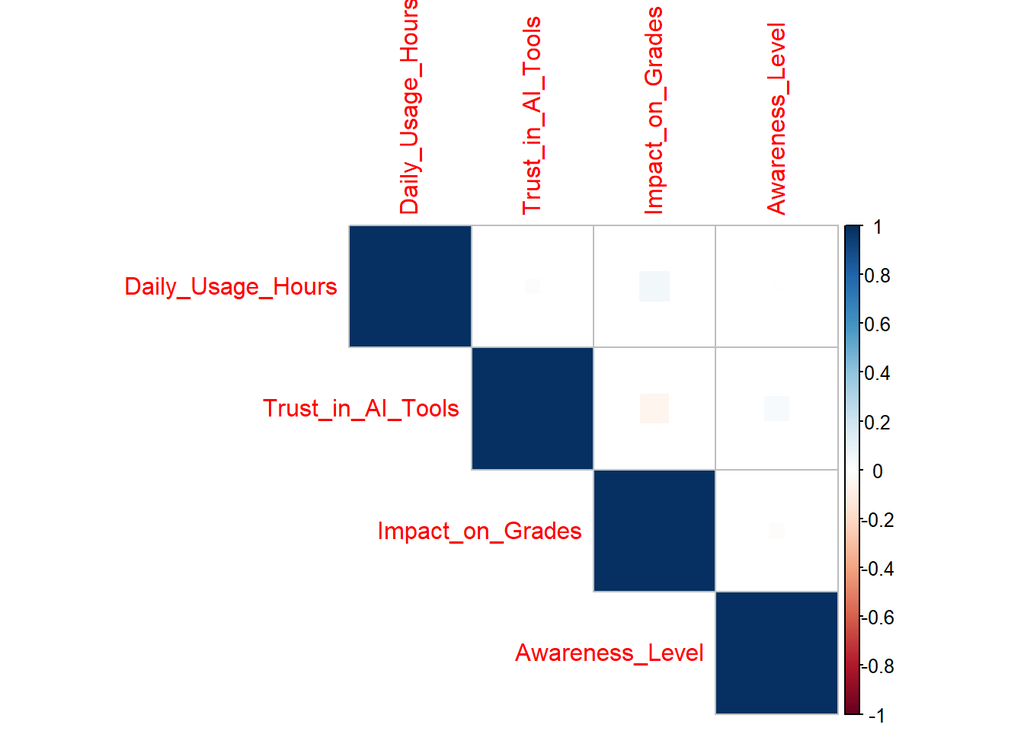

```r
corrplot(cor_studenci, method = "square", type = "upper")
```

Po analizie macierzy korelacji można dostrzec brak silnych zależności pomiędzy zmiennymi liczbowymi. Wartości współczynników korelacji są niskie, co sugeruje, że badane zmienne nie są ze sobą silnie powiązane.

## Statystyki i analizy

Najciekawszym zagadnieniem wydaje się zaufanie studentów do AI.

```r
table(studenci_AI$Trust_in_AI_Tools)
```

```
##
##   1   2   3   4   5
## 714 750 685 668 797
```

```r
summary(studenci_AI$Trust_in_AI_Tools)
```

```
##    Min. 1st Qu.  Median    Mean 3rd Qu.    Max.
##   1.000   2.000   3.000   3.023   4.000   5.000
```

Według powyższych podsumowań najliczniejszą grupą są studenci, którzy deklarują pełne zaufanie do AI.

Warto sprawdzić, czy na zaufanie wpływa rok studiów.

```r
studenci_AI %>% group_by(Year_of_Study) %>% count(Trust_in_AI_Tools)
```

| Year_of_Study | Trust_in_AI_Tools | n |
| --- | --- | --- |
| 1 | 1 | 214 |
| 1 | 2 | 156 |
| 1 | 3 | 181 |
| 1 | 4 | 150 |
| 1 | 5 | 201 |
| 2 | 1 | 191 |
| 2 | 2 | 186 |
| 2 | 3 | 165 |
| 2 | 4 | 194 |
| 2 | 5 | 230 |

[output cut: 10 more lines]

```r
studenci_AI %>% group_by(Year_of_Study) %>%
  summarise( srednie_zaufanie = mean(Trust_in_AI_Tools),
             mediana_zaufania = median(Trust_in_AI_Tools),
             odchylenie = sd(Trust_in_AI_Tools))
```

| Year_of_Study | srednie_zaufanie | mediana_zaufania | odchylenie |
| --- | --- | --- | --- |
| 1 | 2.964523 | 3 | 1.476740 |
| 2 | 3.089027 | 3 | 1.459769 |
| 3 | 3.054484 | 3 | 1.369881 |
| 4 | 2.979191 | 3 | 1.434377 |

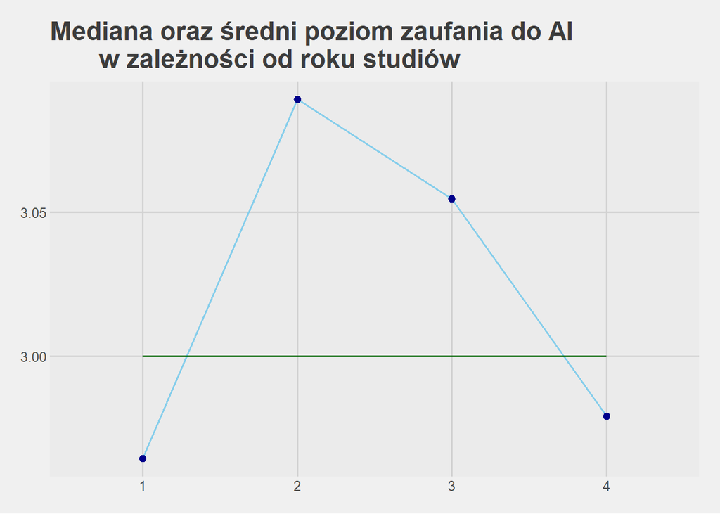

```r
studenci_AI %>% group_by(Year_of_Study) %>%
  summarise(srednie_zaufanie = mean(Trust_in_AI_Tools),
            mediana_zaufanie = median(Trust_in_AI_Tools)) %>%
  ggplot(aes(x = Year_of_Study, y = srednie_zaufanie , group = 1)) +
  geom_line(aes(y = srednie_zaufanie, colour = "średnia"), colour = "skyblue") +
  geom_point(size = 2, colour = "darkblue") +
  geom_line(aes(y = mediana_zaufanie, colour = "mediana"), colour = "darkgreen") +
  theme_fivethirtyeight() +
  labs(title = "Mediana oraz średni poziom zaufania do AI
       w zależności od roku studiów",
       x = "Rok studiów",
       y = "Poziom zaufania do AI")
```

Z podsumowania wynika, że średnia zaufania jest najmniejsza w pierwszym roku studiów, w drugim jest największa, a następnie nieznacznie maleje. Różnice między latami są niewielkie. Mediana na każdym roku studiów pozostaje taka sama. Wyniki nie są zaskakujące, ponieważ można przypuszczać, że wraz z kolejnymi latami studiów rośnie poziom wiedzy, a on powinien wpływać na większą świadomość użytkownika na temat błędów AI. Na podstawie tych danych nie można potwierdzić tej zależności, zaskakujące jest to, że zaufanie maleje bardzo wolno i dopiero od drugiego roku.

Warto też sprawdzić czy i w jakim stopniu wzrost poziomu świadomości użytkownika ma wpływ na zaufanie do AI.

```r
studenci_AI %>%
  select(Awareness_Level, Trust_in_AI_Tools) %>%
  cor(method = "spearman")
```

```
##                   Awareness_Level Trust_in_AI_Tools
## Awareness_Level        1.00000000        0.03737067
## Trust_in_AI_Tools      0.03737067        1.00000000
```

Obliczony poziom korelacji pokazuje minimalną zależność pomiędzy powyższymi danymi. Wpływ jest tak mały, że można przyjąć, że sama zmiana poziomu świadomości użytkownika nie wpływa na zaufanie do narzędzi AI.

Sprawdzę, też czy poziom świadomości użytkownika różni się w zależności od roku studiów.

```r
studenci_AI %>% group_by(Year_of_Study) %>%
  summarise( srednie_swiadomosci = mean(Awareness_Level),
             mediana_swiadomosci = median(Awareness_Level),
             odchylenie = sd(Awareness_Level))
```

| Year_of_Study | srednie_swiadomosci | mediana_swiadomosci | odchylenie |
| --- | --- | --- | --- |
| 1 | 5.586475 | 6 | 2.920849 |
| 2 | 6.288820 | 7 | 2.953600 |
| 3 | 5.730988 | 6 | 2.853874 |
| 4 | 5.665896 | 6 | 2.918738 |

Również w tym przypadku nie widać wyraźnego trendu wzrostowego wraz z kolejnymi latami studiów. Z podsumowania wynika, że najwyższy poziom świadomości przypada w 2 roku studiów, a później spada. Wyniki sugerują, że rok studiów nie jest czynnikiem silnie różnicującym poziom świadomości studentów na temat AI.

Do tej pory analiza przypadków nie wykazała znacznego oddziałowywania na siebie badanych zmiennych.

Szukając wpływu na poziom świadomości użytkownika na temat sztucznej inteligencji nie można pominąć także czasu użytkowania narzędzia. Czy czas który studenci poświęcają na użytkowanie modeli AI, ma wpływ na świadomość?

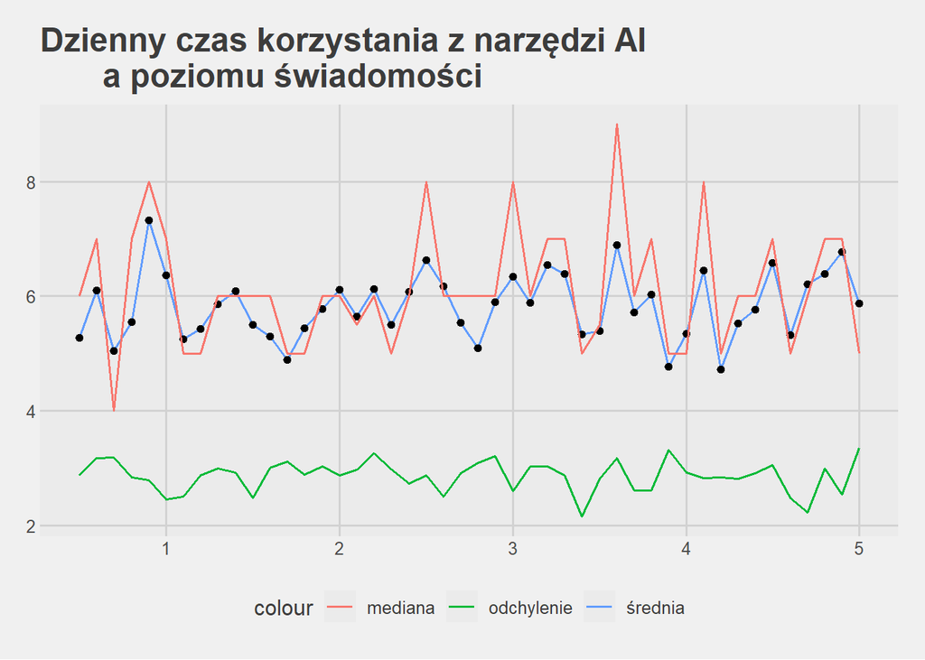

```r
studenci_AI %>% group_by(Daily_Usage_Hours) %>%
  summarise( srednia_uzycia = mean(Awareness_Level),
             mediana_uzycia = median(Awareness_Level),
             odchylenie_uzycia = sd(Awareness_Level)) %>%
  ggplot(aes(x = Daily_Usage_Hours, y = Awareness_Level , group = 1)) +
  geom_line(aes(y = srednia_uzycia, colour = "średnia")) +
  geom_point(aes(y = srednia_uzycia)) +
  geom_line(aes(y = mediana_uzycia, colour = "mediana")) +
  geom_line(aes(y = odchylenie_uzycia, colour = "odchylenie")) +
  theme_fivethirtyeight() +
  labs(title = "Dzienny czas korzystania z narzędzi AI
       a poziomu świadomości",
       x = "Czas korzystania z AI",
       y = "Poziom świadomości")
```

Ze względu na wiele unikalnych wartości i małą liczebność obserwacji, wyniki analizy nie są jednoznaczne. Zasadne byłoby tutaj pogrupować czas użytkowania w przedziały.

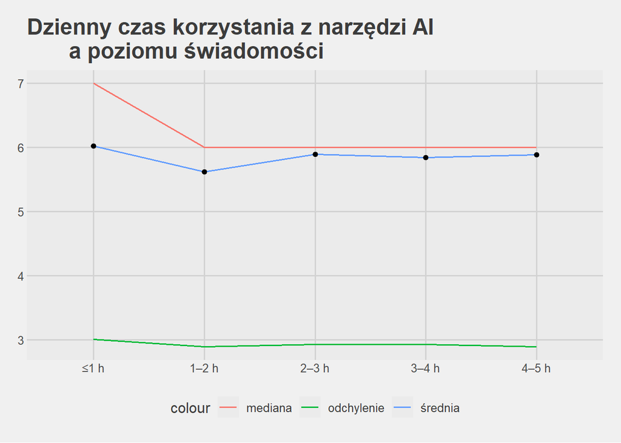

```r
studenci_AI_czas <- studenci_AI %>% mutate(
    czas_uzywania = cut(Daily_Usage_Hours,
      breaks = c(0, 1, 2, 3, 4, 5),
      labels = c("≤1 h", "1–2 h", "2–3 h", "3–4 h", "4–5 h"),
      include.lowest = TRUE))

studenci_AI_czas %>% group_by(czas_uzywania) %>%
  summarise( srednia_uzycia = mean(Awareness_Level),
             mediana_uzycia = median(Awareness_Level),
             odchylenie_uzycia = sd(Awareness_Level)) %>%
  ggplot(aes(x = czas_uzywania, y = Awareness_Level , group = 1)) +
  geom_line(aes(y = srednia_uzycia, colour = "średnia")) +
  geom_point(aes(y = srednia_uzycia)) +
  geom_line(aes(y = mediana_uzycia, colour = "mediana")) +
  geom_line(aes(y = odchylenie_uzycia, colour = "odchylenie")) +
  theme_fivethirtyeight() +
  labs(title = "Dzienny czas korzystania z narzędzi AI
       a poziomu świadomości",
       x = "Czas korzystania z AI",
       y = "Poziom świadomości")
```

Na podstawie tych danych nie widać trendu wskazującego na wzrost poziomu świadomości na temat AI wraz ze wzrostem dziennego użytkowania.

Czy wyższe zaufanie do AI wiąże się z lepszą oceną jego wpływu na oceny?

```r
cor(studenci_AI$Trust_in_AI_Tools, studenci_AI$Impact_on_Grades, method = "spearman")
```

```
## [1] -0.05187687
```

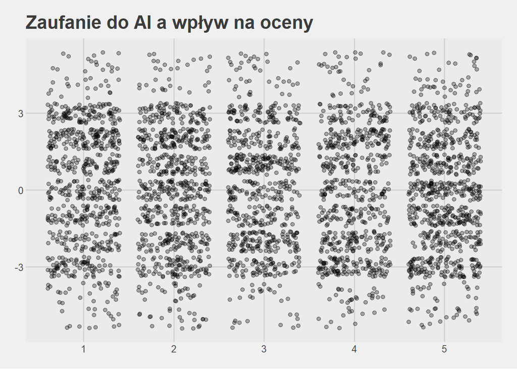

```r
studenci_AI %>%
  ggplot(aes(x = Trust_in_AI_Tools, y = Impact_on_Grades)) +
  geom_jitter(alpha = 0.3) +
  theme_fivethirtyeight() +
  labs(title = "Zaufanie do AI a wpływ na oceny",
       x = "Poziom zaufania do AI",
       y = "Wpływ na oceny")
```

Obliczona korelacja pokazuje niewielki ujemny wpływ zaufania na opinie studentów n.t. wpływu AI na oceny.

Sprawdzę teraz, czy rok studiów wpływa na intensywność korzystania z AI.

```r
studenci_AI %>%
  group_by(Year_of_Study) %>%
  summarise( srednia_czasu = mean(Daily_Usage_Hours),
             mediana_czasu = median(Daily_Usage_Hours))
```

| Year_of_Study | srednia_czasu | mediana_czasu |
| --- | --- | --- |
| 1 | 2.499667 | 2.6 |
| 2 | 2.628986 | 2.8 |
| 3 | 2.548468 | 2.6 |
| 4 | 2.556301 | 2.5 |

Najbardziej intensywnym wydaje się być drugi rok studiów. Ankietowani studiujący na tym roku używają narzędzi AI najdłużej.

Przy poznawaniu zmiennych zauważyłam, że w używanych narzędziach AI przeważa ChatGPT. Ma on możliwość wybrania narzędzia, a najpopularniejszy (i domyślny) jest model językowy. Czy najczęściej używany jest przez humanistów? Czy jest zależność między wyborem narzędzia a kierunkiem studiów?

```r
table(studenci_AI$AI_Tools_Used, studenci_AI$Stream)
```

```
##
##                            Agriculture Arts Commerce Engineering
##   Bard                              19   28       17          13
##   ChatGPT                           33   74       68          68
##   ChatGPT, Copilot                  11   35       36         117
##   ChatGPT, Gemini, Copilot          22   61       27          87
##   Claude                            22   22       23          20
##   Copilot                           58   92       66          58
##   Gemini                            50   48       58          83
##   Gemini, Midjourney                33   38       51          36
##   Other                             14   15       18          23
##
##                            Hotel-management Law Management Medical Pharmacy
##   Bard                                   11  12         13      15        7
##   ChatGPT                                62  38         69      56       54
##   ChatGPT, Copilot                       35  33        102      25       30
##   ChatGPT, Gemini, Copilot               50  23         25      37       20
##   Claude                                 12  12         21      18        7
##   Copilot                                49  43         48      37       39
##   Gemini                                 57  41         54      49       44
##   Gemini, Midjourney                     30  29         30      34       36
##   Other                                  12  15         18      10       15
##
##                            Science
##   Bard                          16
##   ChatGPT                      104
##   ChatGPT, Copilot              81
##   ChatGPT, Gemini, Copilot      74
##   Claude                        14
##   Copilot                       95
##   Gemini                       128
##   Gemini, Midjourney            54
##   Other                         27
```

Ograniczam tabelę do wyboru narzędzia ChatGPT

```r
wgdziedziny <- studenci_AI %>% count(Stream, name = "total")
uzytkownicy <- studenci_AI %>% filter(grepl("ChatGPT", AI_Tools_Used)) %>%
      count(Stream, name = "uzytChatGPT")
uzyt_chatgpt <- left_join(uzytkownicy, wgdziedziny, by = "Stream")

uzyt_chatgpt <- uzyt_chatgpt %>%
  mutate(udzial = uzytChatGPT/total)
```

Wykres użytkowników ChataGPT wg. dziedziny studiów:

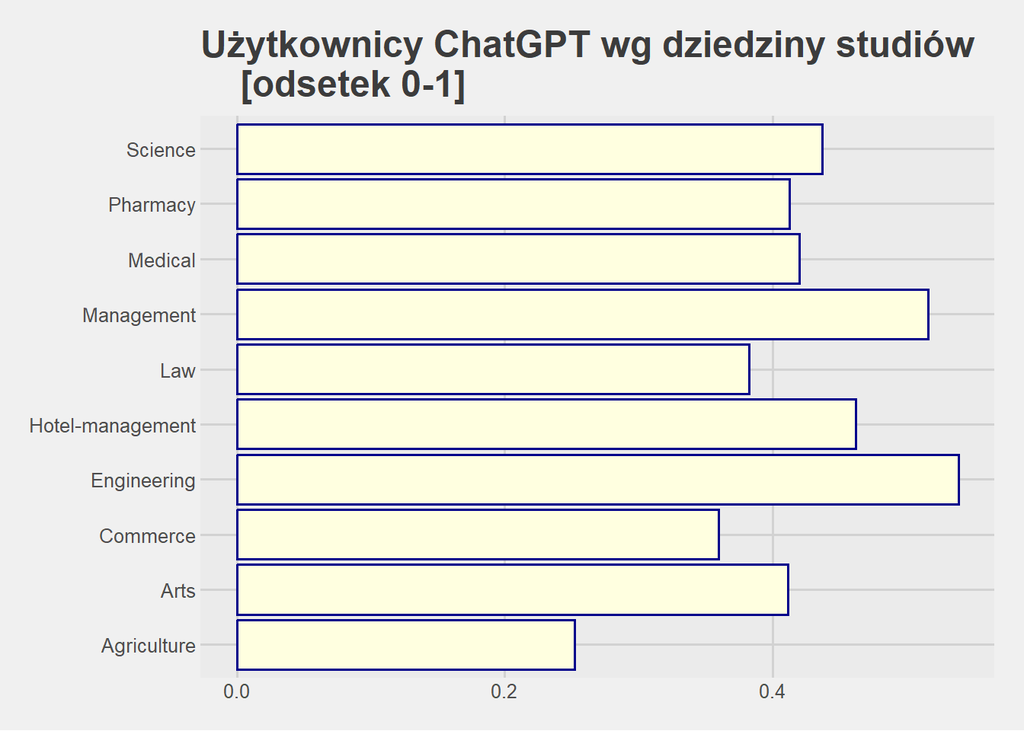

```r
uzyt_chatgpt %>%
  ggplot(aes(x = Stream, y = udzial)) +
  geom_col(fill = "lightyellow", colour = "darkblue") +
  theme_fivethirtyeight() + coord_flip() +
  labs(
    title = "Użytkownicy ChatGPT wg dziedziny studiów
    [odsetek 0-1]",
    x = "Dziedzina studiów",
    y = "Odsetek odpowiedzi")
```

Na wykresie przedstawiłam odsetek odpowiedzi, które zawierały “ChatGPT”, w poszczególnych grupach dziedzin studiów. Na jego podstawie można stwierdzić, że to narzędzie jest najpopularniejsze wśród kierunków Inżynieryjnych, a zaraz po tym kierunki Zarządzania/Menadżerskie.

Sprawdzę więc jeszcze, czy jest zależność między kierunkiem studiów a preferowanym narzędziem.

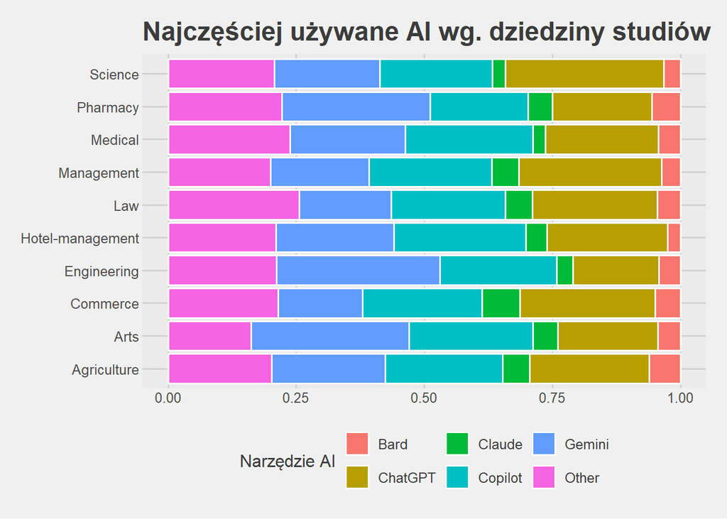

```r
studenci_AI %>%
  ggplot(aes(x = Stream, fill = Preferred_AI_Tool)) +
  geom_bar(position = "fill", colour = "white") +
  theme_fivethirtyeight()+
  coord_flip() +
  labs(
    title = "Najczęściej używane AI wg. dziedziny studiów",
    x = "Dziedzina studiów",
    y = "Ilość odpowiedzi",
    fill = "Narzędzie AI")
```

Nie ma grup, które wyraźnie preferowałyby konkretne narzędzie. Jednak widać duże zróżnicowanie w każdej dziedzinie studiów. Może to wynikać z różnic użyteczności danych narzędzi.

Jak kształtuje się przyzwolenie na używanie narzędzi AI na poszczególnych kierunkach studiów?

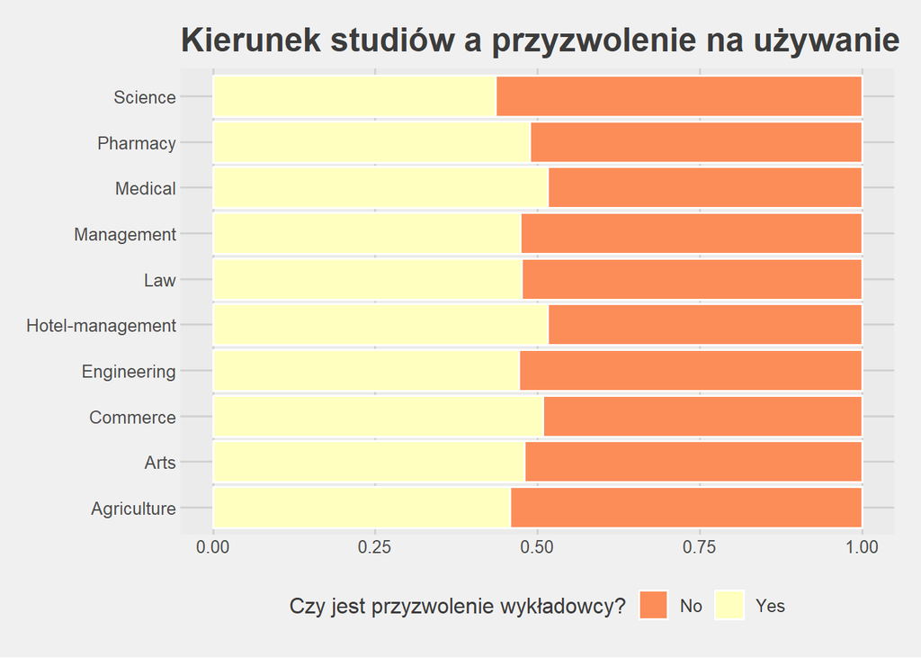

```r
studenci_AI %>%
  ggplot() +
  geom_bar(aes(x = Stream, fill = Do_Professors_Allow_Use),
           colour = "white",
           position = "fill") +
  scale_fill_brewer(palette="RdYlGn") +
  theme_fivethirtyeight() +
  coord_flip() +
  labs(title = "Kierunek studiów a przyzwolenie na używanie",
       x = "Kierunek studiów",
       y = "Odsetek odpowiedzi",
       fill = "Czy jest przyzwolenie wykładowcy?")
```

Wyniki są dość zróżnicowane, na większości kierunków przeważa brak przyzwolenia na użycie AI. Największe przyzwolenie mają studenci Hotel-management, Medical oraz Commerce, ale nie jest ono znacząco większe.

Nie ma wyraźnej zależności między kierunkiem studiów, a podejściem wykładowców do kwestii użytkowania AI.

# Podsumowanie

Celem niniejszej eksploracyjnej analizy danych było poznanie sposobów wykorzystania narzędzi sztucznej inteligencji przez studentów oraz identyfikacja potencjalnych zależności pomiędzy wybranymi cechami, postawami i zachowaniami użytkowników oraz wpływów zewnętrznych. Analiza objęła zarówno zmienne ilościowe, jak i jakościowe, a także ich wzajemne relacje. Analiza pokazała, że studenci z Indii dość intensywnie używają AI. Nie znalazłam wyraźnych wpływów ani silnych zależności. Powyższa EDA może być początkiem do głębszej interpretacji zachowań studentów w kontekście korzystania z AI.

# Bibliografia

Dane ogólne na temat AI w Polsce  
https://kpmg.com/pl/pl/media/korzysta-z-ai-regularnie-przewaznie-bez-zadnego-przeszkolenia-i-czesto-bez-wiedzy-pracodawcy.html

Zestaw danych użytych do analizy  
https://www.kaggle.com/datasets/rakeshkapilavai/ai-tool-usage-by-indian-college-students-2025

Zgłębianie wiedzy na temat Eksploracyjnej Analizy Danych  
https://pl.wikipedia.org/wiki/Eksploracja_danych  
https://pl.wikipedia.org/wiki/Badania_eksploracyjne  
https://astrafox.pl/slownik/exploratory-data-analysis-eda/

W EDA użyto materiały:

- wykłady oraz przykładowe EDA, autor: dr Jacek Wolak
- wykłady oraz materiały dodatkowe, autor: dr Beata Basiura
- materiały z ćwiczeń, autor: mgr Agnieszka Choczyńska
- darmowe samouczki oraz ebooki
- materiały z kursów na platformie DataCamp